# Freshwater, cyclone and upwelling predictors for GBR mortality

AIMS extraction, 2024 context and a practical GBR-wide design

Published

August 26, 2026

## Decision summary

The AIMS data are useful, but they should be a **calibration and validation layer**, not the only freshwater predictor. The portal provides direct salinity, suspended solids, CDOM, Secchi depth and chlorophyll observations at monitored stations. These observations are too sparse to interpolate blindly across the GBR, and many low-salinity stations are near river mouths rather than on reefs.

The practical GBR-wide freshwater model is therefore a two-part model:

1. predict the probability of ecologically important freshwater exposure (minimum salinity below 30 PSU); and
2. conditional on exposure, predict its magnitude or freshwater deficit.

The predictors should combine event-timed rainfall, IMOS optical plume information, cyclone exposure and spatial connectivity to river sources. The historical eReefs salinity field remains useful as a broad physical prior, but the AIMS measurements should calibrate its bias. The final reef prediction must carry uncertainty that increases with distance from AIMS observations.

The first reef-blocked screen is a useful negative result. Rainfall, IMOS Kd490, RRN water colour and cyclone proximity only modestly improve detection of salinity below 30 PSU, and none of the candidates estimates freshwater severity accurately enough for production use.

The cyclone track layer is immediately useful and resolves an exposure signal that the existing RRN 4 m wave-hours variable did not consistently recover. It should remain separate from freshwater and wave damage: track proximity is a forcing indicator, not proof of either mechanism.

For upwelling, a single static shelf category is not adequate. We need an event-specific cooling/refugia layer derived from high-resolution daily SST, with a second subsurface intrusion component. This is an ameliorating modifier of DHW, so its main model role is an interaction with heat stress.

## What the 2024 manuscript changes

The attached 2024 impact manuscript reports surveys of 124 reefs and record single-year coral-cover declines in the Northern and Southern GBR. Acropora accounted for much of both the preceding gains and subsequent losses. The most important modelling result is the contrast around Lizard Island: outer-shelf reefs with approximately 7.3–7.6 DHW had negligible mortality, while inshore reefs with lower heat exposure experienced severe mortality. The outer-shelf reefs experienced a local 1–1.5 degrees C cooling during the heatwave, consistent with hydrodynamic relief. Jasper, flooding and low salinity were also implicated in the northern losses.

This supports four changes already being developed in the mortality pipeline:

- retain pre-event coral composition, especially Acropora;
- represent freshwater as an event-specific DHW modifier;
- add cyclone forcing without conflating wave damage and flood exposure; and
- add upwelling/cooling relief as a DHW interaction.

The manuscript also supports using aerial bleaching severity as a within-event nowcast gate. It should improve post-event forecasts, but cannot be used for a fully pre-season prediction.

## AIMS data recovered

The extraction uses the public [AIMS water-quality portal](https://data.aims.gov.au/water-quality/) and is reproducible with `scripts/extract_aims_water_quality.R`. Inspection of the portal application recovered its all-programme/MMP-only, depth-average/depth-weighted and hourly/daily query variants. The primary calibration table uses all programmes, depth averages and observations from 0–10 m; the alternative summaries remain available for sensitivity checks.

| event_year | station_events | locations | with_salinity | below_30 | below_25 | within_20km_reef |
| --- | --- | --- | --- | --- | --- | --- |
| 2016 | 283 | 112 | 283 | 40 | 27 | 283 |
| 2017 | 224 | 86 | 223 | 50 | 31 | 224 |
| 2018 | 281 | 139 | 281 | 91 | 63 | 276 |
| 2019 | 319 | 153 | 318 | 136 | 88 | 310 |
| 2020 | 227 | 132 | 191 | 19 | 14 | 220 |
| 2021 | 338 | 132 | 336 | 66 | 44 | 325 |
| 2022 | 371 | 151 | 371 | 65 | 38 | 351 |
| 2023 | 354 | 138 | 354 | 68 | 37 | 335 |
| 2024 | 468 | 216 | 462 | 101 | 59 | 450 |
| 2025 | 402 | 155 | 402 | 131 | 76 | 390 |

The all-programme depth-averaged download contains 6,366 sample-depth rows. After retaining ecologically relevant shallow observations (0–10 m), there are 3,267 station-event summaries; 2193 are within 5 km and 3164 are within 20 km of a GBR reef registry point. The processed archive contains 3823 station sampling dates after shallow samples are aggregated.

All-programme depth-average coverage by project

| PROJECT | rows | locations | salinity_rows | first_event | last_event |
| --- | --- | --- | --- | --- | --- |
| MMP-AIMS | 2071 | 311 | 2064 | 2016 | 2025 |
| MMP-JCU | 1940 | 413 | 1917 | 2016 | 2025 |
| MMP-CY | 1582 | 305 | 1556 | 2018 | 2025 |
| LTMP-DIC | 391 | 366 | 385 | 2016 | 2025 |
| Unspecified | 289 | 87 | 69 | 2018 | 2025 |
| MBM | 93 | 31 | 31 | 2024 | 2024 |

The expanded query adds MBM and LTMP-DIC reef observations that are absent from an MMP-only export. A server quirk also matters for reproducibility: `mmpOnly` is not encoded in the generated archive filename, so the extraction uses a distinct bounding-box string for the all-programme request to prevent a cached MMP-only archive masking the broader result.

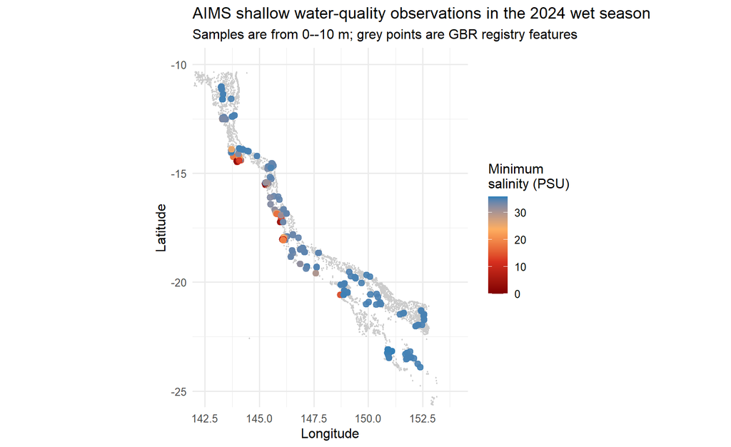

### Important limitation: the continuous logger gap

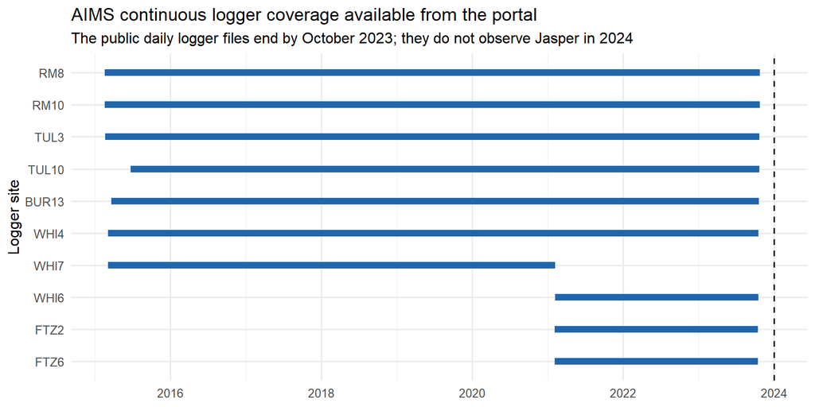

This is not a join error: the latest timestamp in the downloaded hourly logger files is 2023-10-25 11:00:00. Hourly data matter: 43 historical site-events contain at least one hour below 30 PSU, and short pulses can be hidden by daily averages. The discrete record does include 2024, but it is intermittent. It also includes LTMP-DIC, MBM and legacy projects when the API’s `mmpOnly=false` option is used; this is why it recovers reef samples that an MMP-only export misses.

Recovered 2024 observations at target northern reefs

| Project | Location | Matched reef | Depth range (m) | Minimum salinity (PSU) | Sampling dates | Match method | Distance to reef (km) |
| --- | --- | --- | --- | --- | --- | --- | --- |
| LTMP-DIC | Eyrie Reef | Eyrie Reef (14-118) | 0–0 | 34.26 | 1 | unique survey name | 3.1 |
| LTMP-DIC | Linnet Reef | Linnet Reef (14-126) | 0–0 | 33.28 | 1 | unique survey name | 2.1 |
| NA | Lizard Island north | South (Newt) Island (14-116c) | 5–5 | 35.31 | 1 | nearest registry point | 2.0 |
| NA | Lizard Island north | South (Newt) Island (14-116c) | 5–5 | 33.81 | 1 | nearest registry point | 2.0 |
| LTMP-DIC | Lizard Isles | Lizard Island Reef (North West) (14-116a) | 0–0 | 35.33 | 1 | unique survey name | 1.5 |
| MBM | Mackay Reef | Mackay Reef (16-015) | 5–5 | 33.95 | 1 | unique survey name | 1.1 |
| LTMP-DIC | Swinger Reef | Swinger Reef (15-030) | 0–0 | 34.30 | 1 | unique survey name | 0.8 |

These measurements demonstrate that the apparent absence at the target reefs was partly an API-filter and depth-filter problem. They do not rule out an earlier Jasper freshwater pulse: most are single visits, and a later value near 34 PSU cannot establish the event minimum. Mackay’s measurement was at 5 m in late February, roughly two months after Jasper’s December flood pulse.

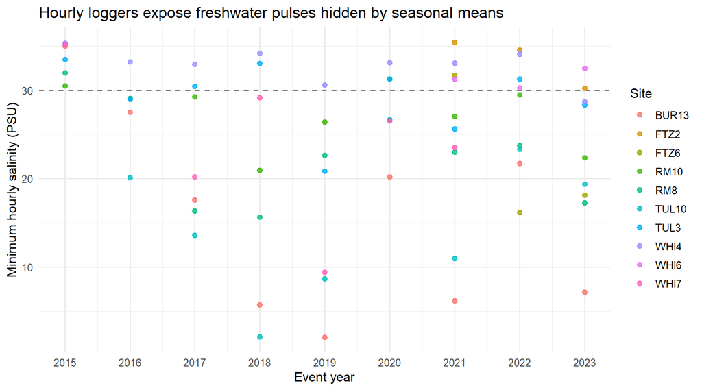

## Freshwater proxy pilot

The first compact hurdle-model screen is complete. It uses five whole-reef folds and keeps 2024 in the validation pool. The occurrence target has 1,034 complete shallow station-events and 190 events below 30 PSU.

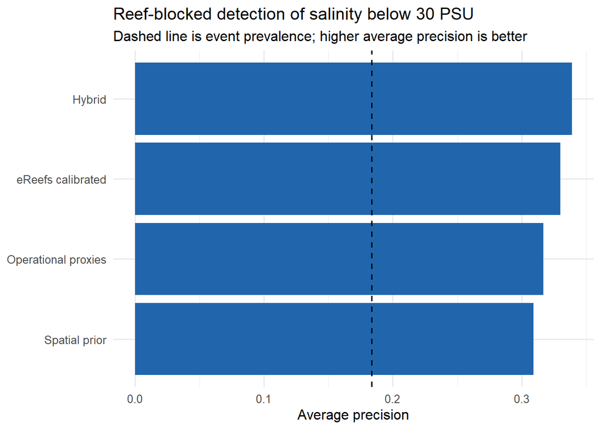

The hybrid has the best overall average precision (0.339), but the gain over eReefs and operational proxies is modest. More importantly, none of the candidates estimates low-salinity magnitude adequately: conditional RMSE is 11.4 PSU and predictions are biased about 5.6 PSU too high. The pilot can rank some exposure risk, but it is not yet suitable for supplying mortality-model salinity magnitudes. Event timing and river-to-reef connectivity are the next necessary additions.

## Cyclone best tracks

The extraction uses the Bureau of Meteorology’s Australian tropical cyclone best-track archive. The Bureau describes these as post-event reanalysed tracks; the source includes time, position, pressure, maximum wind and quadrant wind radii. `scripts/extract_bom_cyclone_exposure.R` creates a complete reef-by-event year table rather than matching only reefs already present in the mortality data.

| Reef | Nearest cyclone | Minimum track distance (km) | Wind at nearest fix (m/s) | Inside reported gale radius |
| --- | --- | --- | --- | --- |
| Mackay Reef (16-015) | Jasper | 31.2 | 25.7 | TRUE |
| Swinger Reef (15-030) | Jasper | 68.1 | 25.7 | TRUE |
| Mackay Reefs (15-024) | Jasper | 77.5 | 25.7 | TRUE |
| Linnet Reef (14-126) | Jasper | 123.7 | 25.7 | FALSE |
| Eyrie Reef (14-118) | Jasper | 129.3 | 25.7 | FALSE |
| Lizard Island reef (14-116d) | Jasper | 129.5 | 25.7 | FALSE |
| Lizard Island reef (14-116a) | Jasper | 131.1 | 25.7 | FALSE |
| Lizard Island reef (14-116b) | Jasper | 132.3 | 25.7 | FALSE |

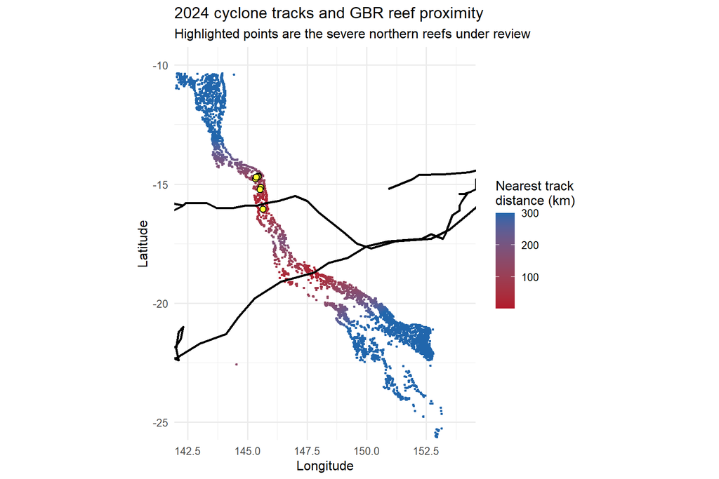

Mackay (16-015), Mackay (15-024) and Swinger have strong Jasper proximity, and the first two are inside or close to the reported gale footprint depending on the quadrant at the nearest fix. Linnet and the Lizard/Eyrie group are still within roughly 120–132 km of Jasper’s track. This supports a regional Jasper forcing variable, but it does not by itself distinguish rainfall/flood plume from wind or wave damage.

## How to generalise freshwater exposure to all GBR reefs

The new file `data/processed/freshwater_predictor_grid_2016_2025.csv` contains the candidate predictors at all 4676 GBR registry features for each AIMS event year. Complete ERA5/eReefs fields currently exist for 2016, 2017, 2020, 2022 and 2024; the RRN and cyclone layers cover a longer period.

The modelling sequence should stay simple and auditable:

1. **Measured target.** Use AIMS minimum salinity and the below-30-PSU flag. Retain sample count and distance to reef. Give river-mouth measurements less leverage on reef-level magnitude, while retaining them for plume detection.
2. **Broad physical prior.** Use eReefs minimum salinity where the forcing is complete, but calibrate it to AIMS rather than assuming it is truth.
3. **Operational proxy model.** Predict exposure from event rainfall, IMOS Kd490/coloured-water anomalies, BoM cyclone forcing and a river-plume connectivity term. RRN coloured-water frequency is a valuable retrospective predictor but must be marked unavailable for real-time use when its release is delayed.
4. **Validation.** Keep 2024 in model development. Use held-out spatial groups or catchments so the model is tested at unseen locations while retaining the only well-observed severe compound event. Report sensitivity with and without 2024, not a single 2024 holdout score.
5. **Mortality model.** Enter the predicted freshwater distribution, not just a plug-in mean, and interact it with DHW. This lets freshwater raise mortality under heat stress without inventing widespread thermal mortality at low DHW.

The one important missing structural predictor is hydrological connectivity: distance from each reef to river mouths is not enough because plume transport is directional. A compact first version can use nearest major river, coastal rainfall/discharge, distance and prevailing current direction. If that performs poorly, replace it with an eReefs-derived source-to-reef connectivity matrix.

## Upwelling and thermal-refuge layer

High-resolution model and satellite work has already identified GBR climate refugia caused by cooler-water upwelling through interactions among tides, currents and reef structure. A separate Central GBR study found 64 intrusive upwelling events in six years: near-bottom temperature commonly fell 1–3 degrees C over about a week, and the cooling was not necessarily visible at the surface. This is why neither shelf position nor SST alone is sufficient.

The first operational version should contain two interpretable components:

[output not shown]

The surface record is available operationally and at useful reef-scale resolution. Copernicus is coarser (about 0.083 degrees), so it should represent large-scale forcing rather than claim reef-scale truth. A static historical refugia probability can be estimated from repeat cool anomalies and used when daily data are absent.

In the mortality model, compare:

```
thermal_effect = f(DHW, composition, prior exposure)
                 + DHW x freshwater_exposure
                 + DHW x cooling_relief
```

The signs should be constrained ecologically: freshwater can exacerbate heat loss and cooling relief can reduce it. A flexible residual term can still learn exceptions, but these interactions prevent the low-DHW background from flattening the severe-loss response.

## Immediate implementation order

1. Add river-source/connectivity fields to the new GBR predictor grid.
2. Add river-source connectivity and event-timed rainfall/optical anomalies to the completed below-30-PSU pilot, then repeat whole-reef validation and the no-2024 sensitivity analysis.
3. Extract the 2024 IMOS SST cooling-residual pilot around Lizard, then extend it to all event years if it reproduces the manuscript contrast.
4. Add Copernicus vertical-velocity/thermal-gradient forcing and validate it at the Central GBR moorings.
5. Pass freshwater and cooling posterior/ensemble predictions into the beta-binomial, BRMS and BRT mortality ensemble as DHW interactions.

The habitat map is intentionally excluded from this sequence. It does not solve the dynamic freshwater or upwelling problem and would add complexity without a clear predictive target.

## Sources

- [AIMS water-quality portal](https://data.aims.gov.au/water-quality/)
- [Bureau of Meteorology tropical cyclone databases](https://www.bom.gov.au/cyclone/tropical-cyclone-knowledge-centre/databases/)
- [IMOS satellite SST products](https://imos.org.au/srs-sst-data)
- [Copernicus Global Ocean Physics Analysis and Forecast](https://data.marine.copernicus.eu/product/GLOBAL_ANALYSISFORECAST_PHY_001_024/description)
- [Sun et al. (2024), climate refugia in the GBR](https://pmc.ncbi.nlm.nih.gov/articles/PMC11606497/)
- [Benthuysen et al. (2016), intrusive upwelling in the Central GBR](https://doi.org/10.1002/2016JC012294)